# predictive-power-moving-averages

## Post Updates

Update 10/29/2026: The analysis has been updated to use month-end data only, incorporates a "base rate" of return for comparison purposes, and updates the conclusions accordingly.

## Introduction

The theory of time series momentum (AKA, trend following) heavily relies on the idea that if the price at time t is higher than the price at time t-x, then the price at time t+y is likely to be higher than the price at time t.

In this post, we will investigate the idea of moving averages, and whether if the price at time t is higher or lower than the moving average up until time t (for several different lookback periods) has any predictive power for forward returns (for several different time horizons).

## Python Imports

```python
# Standard Library
import os
import sys
import warnings

from pathlib import Path

# Data Handling
import pandas as pd

# Suppress warnings
warnings.filterwarnings("ignore")
```

```python
# Add the source subdirectory to the system path to allow import config from settings.py
current_directory = Path(os.getcwd())
website_base_directory = current_directory.parent.parent.parent
src_directory = website_base_directory / "src"
sys.path.append(str(src_directory)) if str(src_directory) not in sys.path else None

# Import settings.py
from settings import config

# Add configured directories from config to path
SOURCE_DIR = config("SOURCE_DIR")
sys.path.append(str(Path(SOURCE_DIR))) if str(Path(SOURCE_DIR)) not in sys.path else None

# Add other configured directories
BASE_DIR = config("BASE_DIR")
CONTENT_DIR = config("CONTENT_DIR")
POSTS_DIR = config("POSTS_DIR")
PAGES_DIR = config("PAGES_DIR")
PUBLIC_DIR = config("PUBLIC_DIR")
SOURCE_DIR = config("SOURCE_DIR")
DATA_DIR = config("DATA_DIR")
DATA_MANUAL_DIR = config("DATA_MANUAL_DIR")
```

## Python Functions

Here are the functions needed for this project:

- load_data: Load data from a CSV, Excel, or Pickle file into a pandas DataFrame.
- pandas_set_decimal_places: Set the number of decimal places displayed for floating-point numbers in pandas.
- plot_heatmap: Plot a heatmap from a DataFrame.
- plot_histogram: Plot the histogram of a data set from a DataFrame.
- plot_scatter: Plot the data from a DataFrame for a specified date range and columns.
- plot_time_series: Plot the timeseries data from a DataFrame for a specified date range and columns.
- run_regression: Run a linear regression using statsmodels OLS and return the results.
- summary_stats: Generate summary statistics for a series of returns.
- yf_pull_data: Download daily price data from Yahoo Finance and export it.

```python
from load_data import load_data
from pandas_set_decimal_places import pandas_set_decimal_places
from plot_heatmap import plot_heatmap
from plot_histogram import plot_histogram
from plot_scatter import plot_scatter
from plot_time_series import plot_time_series
from run_regression import run_regression
from summary_stats import summary_stats
from yf_pull_data import yf_pull_data
```

## Data Overview

For this exercise, we will investigate the predictive power of moving averages for the following ETFs:

- IVV - iShares Core S&P 500 ETF
- EFA - iShares MSCI EAFE ETF
- EEM - iShares MSCI Emerging Markets ETF
- GSG - iShares S&P GSCI Commodity-Indexed Trust
- IAU - iShares Gold Trust
- IEF - iShares 7-10 Year Treasury Bond ETF
- TLT - iShares 20+ Year Treasury Bond ETF

We'll use the adjusted close prices for each of these ETFs.

### Acquire Data

First, let's get the data for these ETFs. If we already have the desired data, we can load it from a local pickle file. Otherwise, we can download it from Yahoo Finance using the `yf_pull_data` function.

```python
pandas_set_decimal_places(2)

# Create a list of the ETF tickers
fund_list = ["IVV", "EFA", "EEM", "GSG", "IAU", "IEF", "TLT"]
```

```python
# Pull data for each ETF and cache it locally
for fund in fund_list:
    yf_pull_data(
        base_directory=DATA_DIR,
        ticker=fund,
        adjusted=False,
        source="Yahoo_Finance",
        asset_class="Exchange_Traded_Funds",
        excel_export=True,
        pickle_export=True,
        output_confirmation=False,
    )
```

### Create Data Dictionary

Then, create a dictionary to hold the data for each ETF.

```python
# Create an empty dictionary to hold the data for each ETF
fund_data = {}

# Load the data for each ETF, rename the columns to include the ticker, store it in the fund_data dictionary
for fund in fund_list:
    data = load_data(
        base_directory=DATA_DIR,
        ticker=fund,
        source="Yahoo_Finance",
        asset_class="Exchange_Traded_Funds",
        timeframe="Daily",
        file_format="pickle",
    )

    data = data.rename(columns={
        "Adj Close": f"{fund}_Adj_Close",
        "Close": f"{fund}_Close",
        "High": f"{fund}_High",
        "Low": f"{fund}_Low",
        "Open": f"{fund}_Open",
        "Volume": f"{fund}_Volume"
    })

    fund_data[fund] = data
```

### Plot Data

Next, we will check the date ranges, and plot the adjusted close prices, cumulative returns, and drawdowns.

```python
for fund, data in fund_data.items():
    print(f"Fund: {fund}")
    print(f"Date Range: {data.index.min()} - {data.index.max()}")
```

```
Fund: IVV
Date Range: 2000-05-19 00:00:00 - 2026-10-28 00:00:00
Fund: EFA
Date Range: 2001-08-27 00:00:00 - 2026-10-28 00:00:00
Fund: EEM
Date Range: 2003-04-14 00:00:00 - 2026-10-28 00:00:00
Fund: GSG
Date Range: 2006-07-21 00:00:00 - 2026-10-28 00:00:00
Fund: IAU
Date Range: 2005-01-28 00:00:00 - 2026-10-28 00:00:00
Fund: IEF
Date Range: 2002-07-30 00:00:00 - 2026-10-28 00:00:00
Fund: TLT
Date Range: 2002-07-30 00:00:00 - 2026-10-28 00:00:00
```

Our shortest range is GSG, with just over 20 years of data.

| Date | IVV_Adj_Close | IVV_Close | IVV_High | IVV_Low | IVV_Open | IVV_Volume |
| --- | --- | --- | --- | --- | --- | --- |
| 2000-05-19 | 88.08 | 140.69 | 142.66 | 140.25 | 142.66 | 775500 |
| 2000-05-22 | 87.53 | 139.81 | 140.59 | 136.81 | 140.59 | 1850600 |
| 2000-05-23 | 86.20 | 137.69 | 140.22 | 137.69 | 140.22 | 373900 |
| 2000-05-24 | 87.49 | 139.75 | 140.06 | 136.66 | 137.75 | 400300 |
| 2000-05-25 | 86.69 | 138.47 | 140.94 | 137.88 | 140.03 | 69600 |
| ... | ... | ... | ... | ... | ... | ... |
| 2026-10-22 | 767.41 | 767.41 | 771.09 | 764.57 | 769.71 | 4262000 |
| 2026-10-23 | 763.25 | 763.25 | 766.86 | 762.04 | 763.26 | 4190600 |
| 2026-10-26 | 768.69 | 768.69 | 771.12 | 765.00 | 765.64 | 2583600 |
| 2026-10-27 | 773.25 | 773.25 | 774.59 | 768.65 | 770.84 | 8862200 |
| 2026-10-28 | 775.65 | 775.65 | 776.75 | 772.69 | 774.86 | 2757200 |

6650 rows × 6 columns

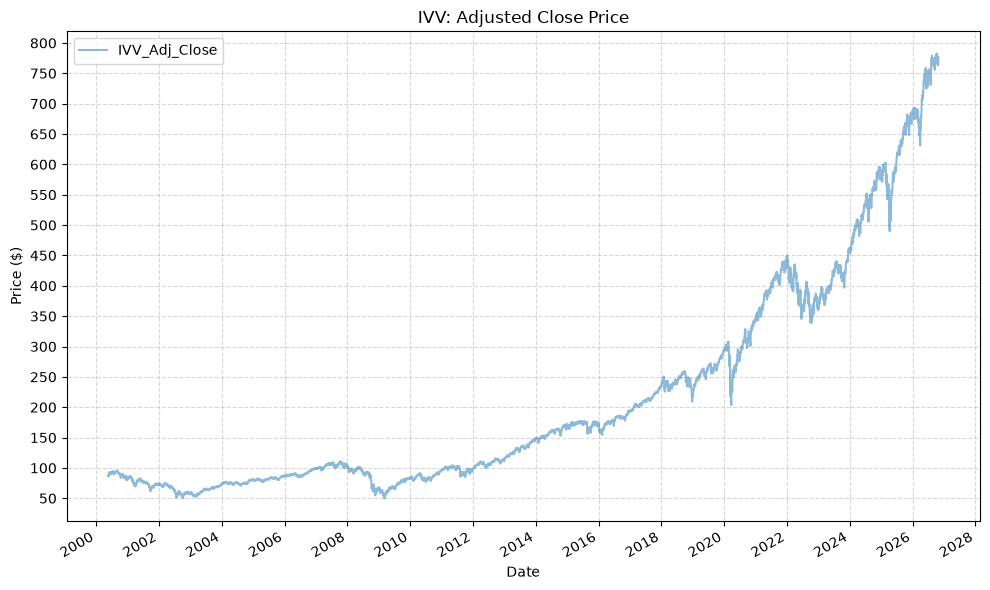

| Date | EFA_Adj_Close | EFA_Close | EFA_High | EFA_Low | EFA_Open | EFA_Volume |
| --- | --- | --- | --- | --- | --- | --- |
| 2001-08-27 | 21.86 | 42.83 | 42.92 | 42.76 | 42.92 | 44700 |
| 2001-08-28 | 21.61 | 42.34 | 42.58 | 42.26 | 42.53 | 319800 |
| 2001-08-29 | 21.51 | 42.15 | 42.47 | 42.10 | 42.45 | 128400 |
| 2001-08-30 | 21.20 | 41.55 | 41.67 | 41.43 | 41.67 | 36900 |
| 2001-08-31 | 21.25 | 41.65 | 41.72 | 41.47 | 41.53 | 1656900 |
| ... | ... | ... | ... | ... | ... | ... |
| 2026-10-22 | 103.15 | 103.15 | 103.47 | 102.79 | 103.26 | 11508000 |
| 2026-10-23 | 102.63 | 102.63 | 102.82 | 102.09 | 102.25 | 9997900 |
| 2026-10-26 | 102.91 | 102.91 | 103.43 | 102.89 | 103.12 | 9119600 |
| 2026-10-27 | 103.59 | 103.59 | 103.71 | 102.97 | 103.12 | 9909100 |
| 2026-10-28 | 103.68 | 103.68 | 103.82 | 103.09 | 103.34 | 12880500 |

6330 rows × 6 columns

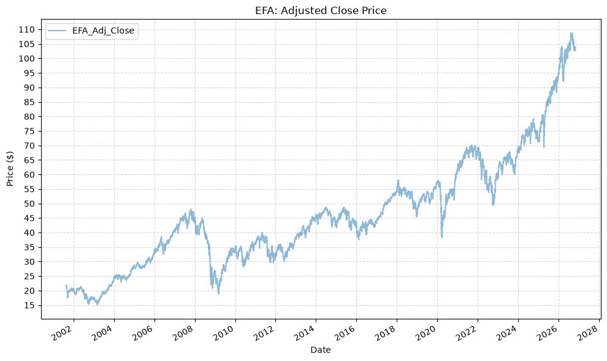

| Date | EEM_Adj_Close | EEM_Close | EEM_High | EEM_Low | EEM_Open | EEM_Volume |
| --- | --- | --- | --- | --- | --- | --- |
| 2003-04-14 | 7.20 | 11.22 | 11.22 | 11.14 | 11.14 | 93600 |
| 2003-04-15 | 7.28 | 11.36 | 11.39 | 11.29 | 11.29 | 421200 |
| 2003-04-16 | 7.37 | 11.49 | 11.53 | 11.48 | 11.48 | 9000 |
| 2003-04-17 | 7.42 | 11.57 | 11.57 | 11.53 | 11.55 | 17100 |
| 2003-04-21 | 7.42 | 11.56 | 11.58 | 11.56 | 11.58 | 72900 |
| ... | ... | ... | ... | ... | ... | ... |
| 2026-10-22 | 61.72 | 61.72 | 62.36 | 61.50 | 62.05 | 28385500 |
| 2026-10-23 | 62.01 | 62.01 | 62.08 | 61.60 | 61.66 | 22024100 |
| 2026-10-26 | 61.82 | 61.82 | 62.08 | 61.25 | 61.29 | 17851100 |
| 2026-10-27 | 62.52 | 62.52 | 62.72 | 62.14 | 62.28 | 23457400 |
| 2026-10-28 | 63.52 | 63.52 | 63.65 | 63.00 | 63.21 | 23641100 |

5924 rows × 6 columns

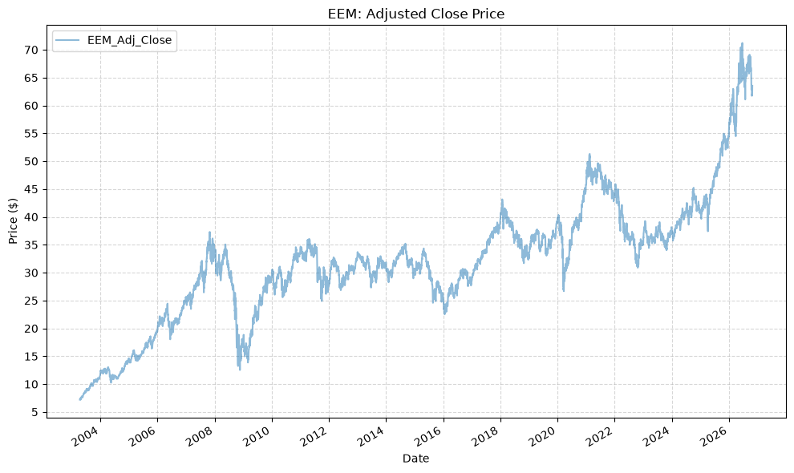

| Date | GSG_Adj_Close | GSG_Close | GSG_High | GSG_Low | GSG_Open | GSG_Volume |
| --- | --- | --- | --- | --- | --- | --- |
| 2006-07-21 | 49.25 | 49.25 | 49.64 | 49.22 | 49.35 | 37400 |
| 2006-07-24 | 49.70 | 49.70 | 49.70 | 48.98 | 49.25 | 220900 |
| 2006-07-25 | 49.25 | 49.25 | 50.15 | 49.20 | 50.15 | 41600 |
| 2006-07-26 | 49.62 | 49.62 | 49.80 | 49.35 | 49.35 | 17800 |
| 2006-07-27 | 50.15 | 50.15 | 50.35 | 49.93 | 50.15 | 41800 |
| ... | ... | ... | ... | ... | ... | ... |
| 2026-10-22 | 36.99 | 36.99 | 37.18 | 36.70 | 37.11 | 2320000 |
| 2026-10-23 | 37.70 | 37.70 | 37.75 | 37.33 | 37.35 | 2325500 |
| 2026-10-26 | 37.31 | 37.31 | 37.65 | 37.07 | 37.30 | 2217800 |
| 2026-10-27 | 36.99 | 36.99 | 37.28 | 36.84 | 37.18 | 782500 |
| 2026-10-28 | 37.15 | 37.15 | 37.46 | 37.15 | 37.22 | 1451500 |

5100 rows × 6 columns

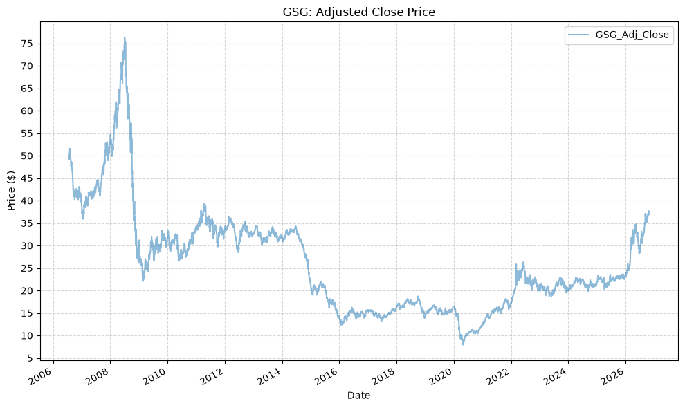

| Date | IAU_Adj_Close | IAU_Close | IAU_High | IAU_Low | IAU_Open | IAU_Volume |
| --- | --- | --- | --- | --- | --- | --- |
| 2005-01-28 | 8.54 | 8.54 | 8.55 | 8.49 | 8.55 | 2888500 |
| 2005-01-31 | 8.45 | 8.45 | 8.46 | 8.40 | 8.45 | 759500 |
| 2005-02-01 | 8.42 | 8.42 | 8.43 | 8.39 | 8.42 | 347500 |
| 2005-02-02 | 8.45 | 8.45 | 8.45 | 8.41 | 8.45 | 1496500 |
| 2005-02-03 | 8.34 | 8.34 | 8.35 | 8.30 | 8.32 | 534000 |
| ... | ... | ... | ... | ... | ... | ... |
| 2026-10-22 | 75.66 | 75.66 | 76.67 | 75.54 | 76.59 | 6251200 |
| 2026-10-23 | 75.15 | 75.15 | 75.71 | 74.70 | 75.64 | 4172600 |
| 2026-10-26 | 75.42 | 75.42 | 75.71 | 74.95 | 75.31 | 5149900 |
| 2026-10-27 | 76.33 | 76.33 | 76.39 | 75.55 | 75.58 | 2816700 |
| 2026-10-28 | 76.57 | 76.57 | 76.58 | 75.64 | 76.15 | 6140900 |

5472 rows × 6 columns

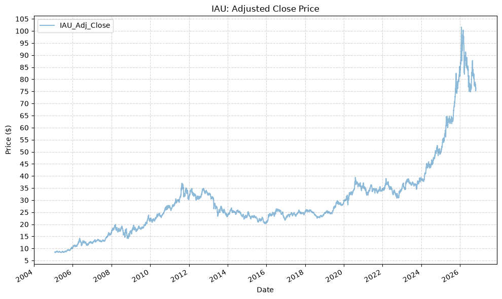

| Date | IEF_Adj_Close | IEF_Close | IEF_High | IEF_Low | IEF_Open | IEF_Volume |
| --- | --- | --- | --- | --- | --- | --- |
| 2002-07-30 | 40.00 | 81.77 | 82.12 | 81.70 | 81.94 | 41300 |
| 2002-07-31 | 40.37 | 82.52 | 82.58 | 82.05 | 82.05 | 32600 |
| 2002-08-01 | 40.53 | 82.86 | 82.90 | 82.52 | 82.54 | 71400 |
| 2002-08-02 | 40.85 | 83.50 | 83.70 | 82.90 | 83.02 | 120300 |
| 2002-08-05 | 41.05 | 83.92 | 83.92 | 83.53 | 83.68 | 159300 |
| ... | ... | ... | ... | ... | ... | ... |
| 2026-10-22 | 91.20 | 91.20 | 91.40 | 90.65 | 90.75 | 16518600 |
| 2026-10-23 | 91.05 | 91.05 | 91.25 | 91.01 | 91.23 | 32715900 |
| 2026-10-26 | 91.12 | 91.12 | 91.27 | 91.04 | 91.16 | 11267200 |
| 2026-10-27 | 91.10 | 91.10 | 91.16 | 90.99 | 91.06 | 19236700 |
| 2026-10-28 | 90.85 | 90.85 | 91.09 | 90.74 | 91.06 | 10812000 |

6102 rows × 6 columns

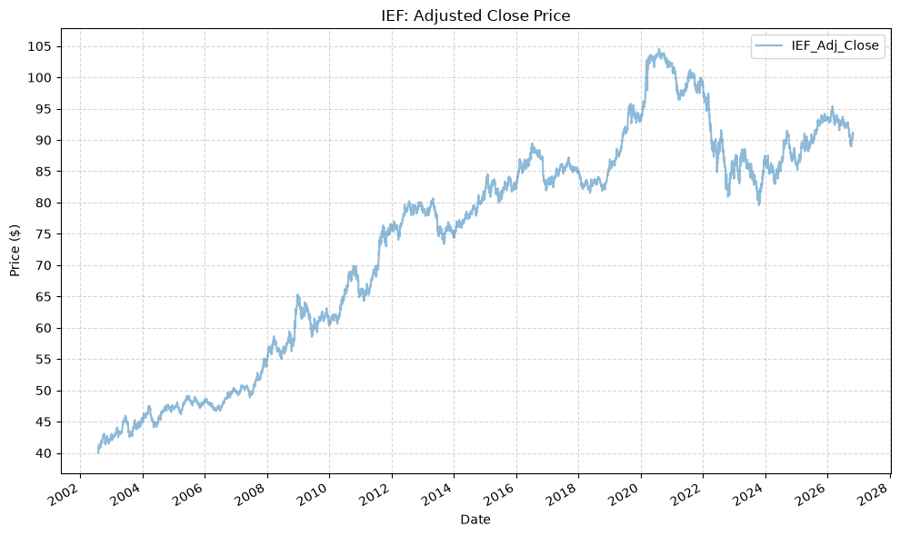

| Date | TLT_Adj_Close | TLT_Close | TLT_High | TLT_Low | TLT_Open | TLT_Volume |
| --- | --- | --- | --- | --- | --- | --- |
| 2002-07-30 | 35.41 | 81.52 | 81.90 | 81.52 | 81.75 | 6100 |
| 2002-07-31 | 35.85 | 82.53 | 82.80 | 81.90 | 81.95 | 29400 |
| 2002-08-01 | 36.06 | 83.00 | 83.02 | 82.54 | 82.54 | 25000 |
| 2002-08-02 | 36.43 | 83.85 | 84.10 | 82.88 | 83.16 | 52800 |
| 2002-08-05 | 36.59 | 84.22 | 84.44 | 83.85 | 84.04 | 61100 |
| ... | ... | ... | ... | ... | ... | ... |
| 2026-10-22 | 81.74 | 81.74 | 81.92 | 80.87 | 81.00 | 65635100 |
| 2026-10-23 | 81.34 | 81.34 | 81.80 | 81.27 | 81.79 | 35149600 |
| 2026-10-26 | 81.68 | 81.68 | 81.90 | 81.54 | 81.66 | 24676500 |
| 2026-10-27 | 81.63 | 81.63 | 81.73 | 81.47 | 81.65 | 19544700 |
| 2026-10-28 | 80.99 | 80.99 | 81.76 | 80.73 | 81.73 | 35127200 |

6102 rows × 6 columns

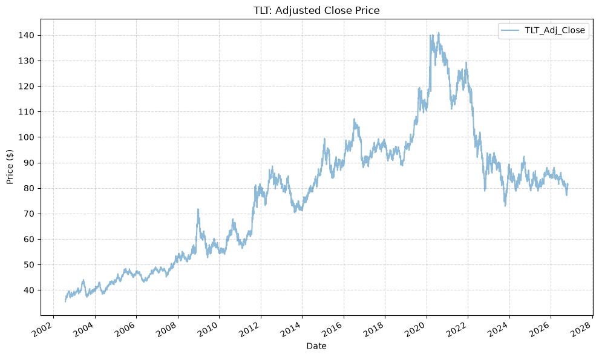

```python
for fund, data in fund_data.items():
    display(data)

    plot_time_series(
        df=data,
        plot_start_date=None,
        plot_end_date=None,
        plot_columns=[f"{fund}_Adj_Close"],
        title=f"{fund}: Adjusted Close Price",
        x_label="Date",
        x_format="Year",
        x_tick_spacing=2,
        x_tick_start=None,
        x_tick_rotation=30,
        y_label="Price ($)",
        y_format="Decimal",
        y_format_decimal_places=0,
        y_tick_spacing="Auto",
        y_tick_rotation=0,
    )
```

```python
# Create empty DF
data_merged = pd.DataFrame()

# Merge all data, calc cumulative returns, drawdowns
for fund, data in fund_data.items():
    data_merged = data_merged.merge(data[[f"{fund}_Adj_Close"]], left_index=True, right_index=True, how='outer') if not data_merged.empty else data[[f"{fund}_Adj_Close"]]
    data_merged[f"{fund}_Return"] = data_merged[f"{fund}_Adj_Close"].pct_change()
    data_merged[f"{fund}_Cumulative_Return"] = (1 + data_merged[f"{fund}_Return"]).cumprod() - 1
    data_merged[f"{fund}_Cumulative_Return_Plus_One"] = 1 + data_merged[f"{fund}_Cumulative_Return"]
    data_merged[f"{fund}_Rolling_Max"] = data_merged[f"{fund}_Cumulative_Return_Plus_One"].cummax()
    data_merged[f"{fund}_Drawdown"] = data_merged[f"{fund}_Cumulative_Return_Plus_One"] / data_merged[f"{fund}_Rolling_Max"] - 1
    data_merged.drop(columns=[f"{fund}_Cumulative_Return_Plus_One", f"{fund}_Rolling_Max"], inplace=True)

display(data_merged)
```

| Date | IVV_Adj_Close | IVV_Return | IVV_Cumulative_Return | IVV_Drawdown | EFA_Adj_Close | EFA_Return | EFA_Cumulative_Return | EFA_Drawdown | EEM_Adj_Close | EEM_Return | ... | IAU_Cumulative_Return | IAU_Drawdown | IEF_Adj_Close | IEF_Return | IEF_Cumulative_Return | IEF_Drawdown | TLT_Adj_Close | TLT_Return | TLT_Cumulative_Return | TLT_Drawdown |
| --- | --- | --- | --- | --- | --- | --- | --- | --- | --- | --- | --- | --- | --- | --- | --- | --- | --- | --- | --- | --- | --- |
| 2000-05-19 | 88.08 | NaN | NaN | NaN | NaN | NaN | NaN | NaN | NaN | NaN | ... | NaN | NaN | NaN | NaN | NaN | NaN | NaN | NaN | NaN | NaN |
| 2000-05-22 | 87.53 | -0.01 | -0.01 | 0.00 | NaN | NaN | NaN | NaN | NaN | NaN | ... | NaN | NaN | NaN | NaN | NaN | NaN | NaN | NaN | NaN | NaN |
| 2000-05-23 | 86.20 | -0.02 | -0.02 | -0.02 | NaN | NaN | NaN | NaN | NaN | NaN | ... | NaN | NaN | NaN | NaN | NaN | NaN | NaN | NaN | NaN | NaN |
| 2000-05-24 | 87.49 | 0.01 | -0.01 | -0.00 | NaN | NaN | NaN | NaN | NaN | NaN | ... | NaN | NaN | NaN | NaN | NaN | NaN | NaN | NaN | NaN | NaN |
| 2000-05-25 | 86.69 | -0.01 | -0.02 | -0.01 | NaN | NaN | NaN | NaN | NaN | NaN | ... | NaN | NaN | NaN | NaN | NaN | NaN | NaN | NaN | NaN | NaN |
| ... | ... | ... | ... | ... | ... | ... | ... | ... | ... | ... | ... | ... | ... | ... | ... | ... | ... | ... | ... | ... | ... |
| 2026-10-22 | 767.41 | -0.01 | 7.71 | -0.02 | 103.15 | -0.01 | 3.72 | -0.05 | 61.72 | -0.03 | ... | 7.86 | -0.26 | 91.20 | 0.01 | 1.28 | -0.13 | 81.74 | 0.02 | 1.31 | -0.42 |
| 2026-10-23 | 763.25 | -0.01 | 7.67 | -0.02 | 102.63 | -0.01 | 3.70 | -0.06 | 62.01 | 0.00 | ... | 7.80 | -0.26 | 91.05 | -0.00 | 1.28 | -0.13 | 81.34 | -0.00 | 1.30 | -0.42 |
| 2026-10-26 | 768.69 | 0.01 | 7.73 | -0.02 | 102.91 | 0.00 | 3.71 | -0.05 | 61.82 | -0.00 | ... | 7.83 | -0.26 | 91.12 | 0.00 | 1.28 | -0.13 | 81.68 | 0.00 | 1.31 | -0.42 |
| 2026-10-27 | 773.25 | 0.01 | 7.78 | -0.01 | 103.59 | 0.01 | 3.74 | -0.05 | 62.52 | 0.01 | ... | 7.94 | -0.25 | 91.10 | -0.00 | 1.28 | -0.13 | 81.63 | -0.00 | 1.31 | -0.42 |
| 2026-10-28 | 775.65 | 0.00 | 7.81 | -0.01 | 103.68 | 0.00 | 3.74 | -0.05 | 63.52 | 0.02 | ... | 7.97 | -0.25 | 90.85 | -0.00 | 1.27 | -0.13 | 80.99 | -0.01 | 1.29 | -0.43 |

6650 rows × 28 columns

And now the plots for the cumulative returns and drawdowns:

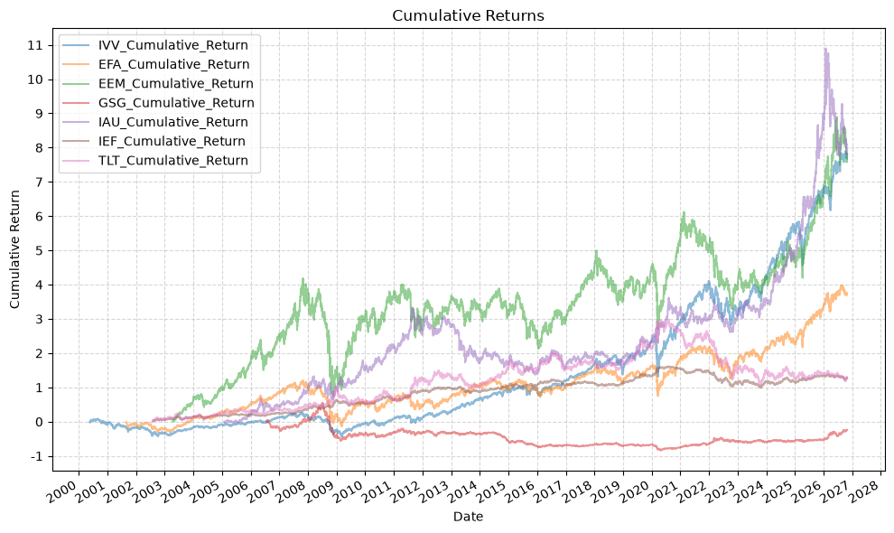

```python
plot_time_series(
    df=data_merged,
    plot_start_date=None,
    plot_end_date=None,
    plot_columns=[col for col in data_merged.columns if "Cumulative_Return" in col],
    title="Cumulative Returns",
    x_label="Date",
    x_format="Year",
    x_tick_spacing=1,
    x_tick_start=None,
    x_tick_rotation=30,
    y_label="Cumulative Return",
    y_format="Decimal",
    y_format_decimal_places=0,
    y_tick_spacing="Auto",
    y_tick_rotation=0,
)
```

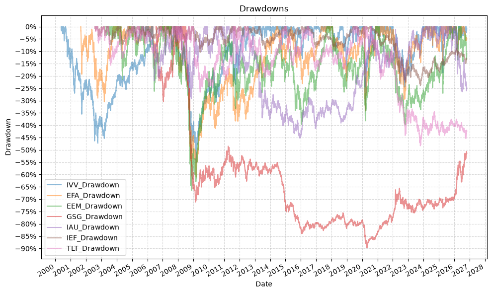

```python
plot_time_series(
    df=data_merged,
    plot_start_date=None,
    plot_end_date=None,
    plot_columns=[col for col in data_merged.columns if "Drawdown" in col],
    title="Drawdowns",
    x_label="Date",
    x_format="Year",
    x_tick_spacing=1,
    x_tick_start=None,
    x_tick_rotation=30,
    y_label="Drawdown",
    y_format="Percentage",
    y_format_decimal_places=0,
    y_tick_spacing="Auto",
    y_tick_rotation=0,
)
```

This time we'll drop the empty rows and normalize the starting values to provide a more accurate comparison, but this will reduce our data set to the inception of GSG in 2006:

```python
# Create empty DF
data_merged_aligned = pd.DataFrame()

# Merge all data, calc cumulative returns, drawdowns
for fund, data in fund_data.items():
    data_merged_aligned = data_merged_aligned.merge(data[[f"{fund}_Adj_Close"]], left_index=True, right_index=True, how='outer') if not data_merged_aligned.empty else data[[f"{fund}_Adj_Close"]]
    data_merged_aligned = data_merged_aligned.dropna()

for fund in fund_data.keys():
    data_merged_aligned[f"{fund}_Return"] = data_merged_aligned[f"{fund}_Adj_Close"].pct_change()
    data_merged_aligned[f"{fund}_Cumulative_Return"] = (1 + data_merged_aligned[f"{fund}_Return"]).cumprod() - 1
    data_merged_aligned[f"{fund}_Cumulative_Return_Plus_One"] = 1 + data_merged_aligned[f"{fund}_Cumulative_Return"]
    data_merged_aligned[f"{fund}_Rolling_Max"] = data_merged_aligned[f"{fund}_Cumulative_Return_Plus_One"].cummax()
    data_merged_aligned[f"{fund}_Drawdown"] = data_merged_aligned[f"{fund}_Cumulative_Return_Plus_One"] / data_merged_aligned[f"{fund}_Rolling_Max"] - 1
    data_merged_aligned.drop(columns=[f"{fund}_Cumulative_Return_Plus_One", f"{fund}_Rolling_Max"], inplace=True)

display(data_merged_aligned)
```

| Date | IVV_Adj_Close | EFA_Adj_Close | EEM_Adj_Close | GSG_Adj_Close | IAU_Adj_Close | IEF_Adj_Close | TLT_Adj_Close | IVV_Return | IVV_Cumulative_Return | IVV_Drawdown | ... | GSG_Drawdown | IAU_Return | IAU_Cumulative_Return | IAU_Drawdown | IEF_Return | IEF_Cumulative_Return | IEF_Drawdown | TLT_Return | TLT_Cumulative_Return | TLT_Drawdown |
| --- | --- | --- | --- | --- | --- | --- | --- | --- | --- | --- | --- | --- | --- | --- | --- | --- | --- | --- | --- | --- | --- |
| 2006-07-21 | 85.73 | 34.42 | 19.76 | 49.25 | 12.37 | 47.66 | 44.81 | NaN | NaN | NaN | ... | NaN | NaN | NaN | NaN | NaN | NaN | NaN | NaN | NaN | NaN |
| 2006-07-24 | 87.19 | 35.04 | 20.65 | 49.70 | 12.22 | 47.66 | 44.79 | 0.02 | 0.02 | 0.00 | ... | 0.00 | -0.01 | -0.01 | 0.00 | 0.00 | 0.00 | 0.00 | -0.00 | -0.00 | 0.00 |
| 2006-07-25 | 87.53 | 35.03 | 20.70 | 49.25 | 12.34 | 47.62 | 44.65 | 0.00 | 0.02 | 0.00 | ... | -0.01 | 0.01 | -0.00 | 0.00 | -0.00 | -0.00 | -0.00 | -0.00 | -0.00 | -0.00 |
| 2006-07-26 | 87.69 | 35.28 | 20.62 | 49.62 | 12.40 | 47.73 | 44.82 | 0.00 | 0.02 | 0.00 | ... | -0.00 | 0.01 | 0.00 | 0.00 | 0.00 | 0.00 | 0.00 | 0.00 | 0.00 | 0.00 |
| 2006-07-27 | 87.58 | 35.50 | 20.90 | 50.15 | 12.59 | 47.73 | 44.75 | -0.00 | 0.02 | -0.00 | ... | 0.00 | 0.02 | 0.02 | 0.00 | -0.00 | 0.00 | -0.00 | -0.00 | -0.00 | -0.00 |
| ... | ... | ... | ... | ... | ... | ... | ... | ... | ... | ... | ... | ... | ... | ... | ... | ... | ... | ... | ... | ... | ... |
| 2026-10-22 | 767.41 | 103.15 | 61.72 | 36.99 | 75.66 | 91.20 | 81.74 | -0.01 | 7.95 | -0.02 | ... | -0.52 | -0.03 | 5.12 | -0.26 | 0.01 | 0.91 | -0.13 | 0.02 | 0.82 | -0.42 |
| 2026-10-23 | 763.25 | 102.63 | 62.01 | 37.70 | 75.15 | 91.05 | 81.34 | -0.01 | 7.90 | -0.02 | ... | -0.51 | -0.01 | 5.08 | -0.26 | -0.00 | 0.91 | -0.13 | -0.00 | 0.82 | -0.42 |
| 2026-10-26 | 768.69 | 102.91 | 61.82 | 37.31 | 75.42 | 91.12 | 81.68 | 0.01 | 7.97 | -0.02 | ... | -0.51 | 0.00 | 5.10 | -0.26 | 0.00 | 0.91 | -0.13 | 0.00 | 0.82 | -0.42 |
| 2026-10-27 | 773.25 | 103.59 | 62.52 | 36.99 | 76.33 | 91.10 | 81.63 | 0.01 | 8.02 | -0.01 | ... | -0.52 | 0.01 | 5.17 | -0.25 | -0.00 | 0.91 | -0.13 | -0.00 | 0.82 | -0.42 |
| 2026-10-28 | 775.65 | 103.68 | 63.52 | 37.15 | 76.57 | 90.85 | 80.99 | 0.00 | 8.05 | -0.01 | ... | -0.51 | 0.00 | 5.19 | -0.25 | -0.00 | 0.91 | -0.13 | -0.01 | 0.81 | -0.43 |

5100 rows × 28 columns

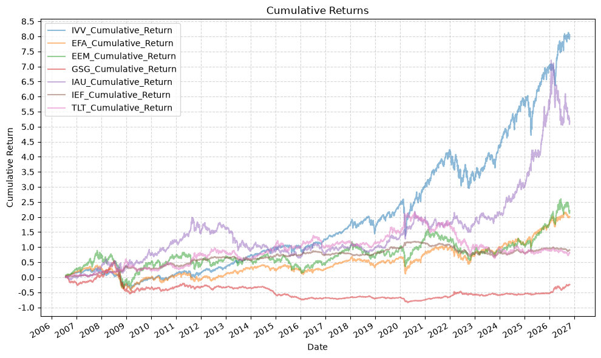

```python
plot_time_series(
    df=data_merged_aligned,
    plot_start_date=None,
    plot_end_date=None,
    plot_columns=[col for col in data_merged_aligned.columns if "Cumulative_Return" in col],
    title="Cumulative Returns",
    x_label="Date",
    x_format="Year",
    x_tick_spacing=1,
    x_tick_start=None,
    x_tick_rotation=30,
    y_label="Cumulative Return",
    y_format="Decimal",
    y_format_decimal_places=1,
    y_tick_spacing="Auto",
    y_tick_rotation=0,
)
```

From the above plot, we can see that US stocks have outperformed all other asset class, but this is since mid-2006, and misses the dotcom bubble of the late 1990s and early 2000s. Right behind US stocks, we have gold, which has made a historic comback since COVID, and at one point had higher cumulative perfomance than US stocks.

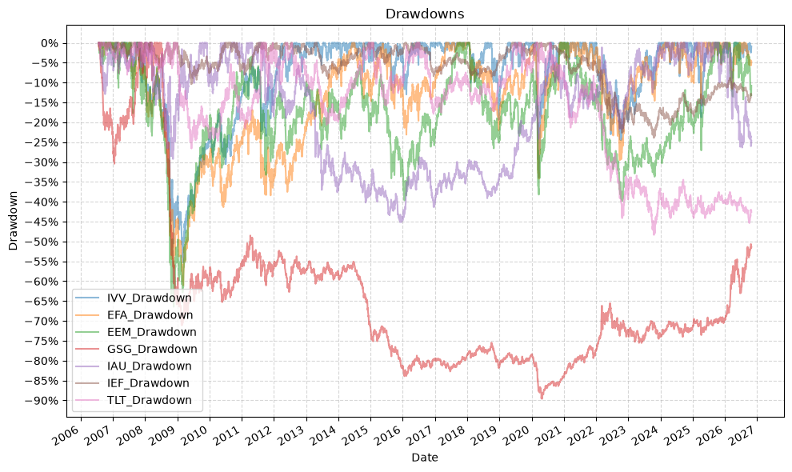

```python
plot_time_series(
    df=data_merged_aligned,
    plot_start_date=None,
    plot_end_date=None,
    plot_columns=[col for col in data_merged_aligned.columns if "Drawdown" in col],
    title="Drawdowns",
    x_label="Date",
    x_format="Year",
    x_tick_spacing=1,
    x_tick_start=None,
    x_tick_rotation=30,
    y_label="Drawdown",
    y_format="Percentage",
    y_format_decimal_places=0,
    y_tick_spacing="Auto",
    y_tick_rotation=0,
)
```

### Summary Statistics

Let's look at the summary statistics. Keep in mind that we are not aligning the dates here, so the number of observations is different for each ETF.

```python
sum_stats = pd.DataFrame()

for fund in fund_data.keys():
    data_stats = summary_stats(
        fund_list=[f"{fund}"],
        df=data_merged[[f"{fund}_Return"]].dropna(),
        period="Daily",
        use_calendar_days=False,
        excel_export=False,
        pickle_export=False,
        output_confirmation=False,
    )

    sum_stats = pd.concat([sum_stats, data_stats])

display(sum_stats)
```

|  | Number of Observations | Data Start Date | Data End Date | Annual Mean Return (Arithmetic) | Annualized Volatility | Annualized Sharpe Ratio | CAGR (Geometric) | Daily Max Return | Daily Max Return (Date) | Daily Min Return | Daily Min Return (Date) | Max Drawdown | Peak | Trough | Recovery Date | Calendar Days to Recovery | MAR Ratio |
| --- | --- | --- | --- | --- | --- | --- | --- | --- | --- | --- | --- | --- | --- | --- | --- | --- | --- |
| IVV_Return | 6649 | 2000-05-22 | 2026-10-28 | 0.10 | 0.19 | 0.53 | 0.09 | 0.11 | 2008-10-28 | -0.12 | 2020-03-16 | -0.55 | 2007-10-09 | 2009-03-09 | 2012-08-16 | 1256.00 | 0.16 |
| EFA_Return | 6329 | 2001-08-28 | 2026-10-28 | 0.08 | 0.21 | 0.40 | 0.06 | 0.16 | 2008-10-13 | -0.11 | 2008-09-29 | -0.61 | 2007-10-31 | 2009-03-09 | 2014-06-06 | 1915.00 | 0.10 |
| EEM_Return | 5923 | 2003-04-15 | 2026-10-28 | 0.13 | 0.27 | 0.48 | 0.10 | 0.23 | 2008-10-13 | -0.16 | 2008-10-15 | -0.66 | 2007-10-31 | 2008-11-20 | 2017-09-18 | 3224.00 | 0.15 |
| GSG_Return | 5099 | 2006-07-24 | 2026-10-28 | 0.01 | 0.23 | 0.06 | -0.01 | 0.08 | 2008-11-04 | -0.12 | 2020-03-09 | -0.90 | 2008-07-02 | 2020-04-28 | NaT | NaN | -0.02 |
| IAU_Return | 5471 | 2005-01-31 | 2026-10-28 | 0.12 | 0.18 | 0.64 | 0.11 | 0.12 | 2008-09-17 | -0.10 | 2026-01-30 | -0.45 | 2011-08-22 | 2015-12-02 | 2020-07-27 | 1699.00 | 0.24 |
| IEF_Return | 6101 | 2002-07-31 | 2026-10-28 | 0.04 | 0.07 | 0.53 | 0.03 | 0.03 | 2009-03-18 | -0.03 | 2020-03-17 | -0.24 | 2020-08-04 | 2023-10-19 | NaT | NaN | 0.14 |
| TLT_Return | 6101 | 2002-07-31 | 2026-10-28 | 0.04 | 0.14 | 0.31 | 0.03 | 0.08 | 2020-03-20 | -0.07 | 2020-03-17 | -0.48 | 2020-08-04 | 2023-10-19 | NaT | NaN | 0.07 |

Note that emerging markets have outperformed all other equity assets when factoring in the drawdown that US markets experienced in the early 2000s.

## Calculate Moving Averages

Now, let's calculate the various different moving averages for each ETF. We will resample the data to use the month end values only, and calculate the 3 - 12 month moving averages.

```python
# Resample to month end values
for fund, data in fund_data.items():
    fund_data[fund] = data.resample('ME').last()
```

```python
# Define moving average windows in months
ma_windows = {
    '3m': 3,     # 3 months (~63 trading days)
    '4m': 4,     # 4 months (~84 trading days)
    '5m': 5,     # 5 months (~105 trading days)
    '6m': 6,     # 6 months (~126 trading days)
    '7m': 7,     # 7 months (~147 trading days)
    '8m': 8,     # 8 months (~168 trading days)
    '9m': 9,     # 9 months (~189 trading days)
    '10m': 10,   # 10 months (~210 trading days)
    '11m': 11,   # 11 months (~231 trading days)
    '12m': 12    # 12 months (~252 trading days)
}
```

```python
for fund, data in fund_data.items():
    for window, months in ma_windows.items():
        data[f"{fund}_MA_{window}"] = data[f"{fund}_Adj_Close"].rolling(window=months).mean()
```

## Calculate Forward Return Windows

Next, we will calculate the forward return for each ETF for the same time periods as the moving averages.

```python
# Define forward return windows in months
fr_windows = {
    '3m': 3,     # 3 months (~63 trading days)
    '4m': 4,     # 4 months (~84 trading days)
    '5m': 5,     # 5 months (~105 trading days)
    '6m': 6,     # 6 months (~126 trading days)
    '7m': 7,     # 7 months (~147 trading days)
    '8m': 8,     # 8 months (~168 trading days)
    '9m': 9,     # 9 months (~189 trading days)
    '10m': 10,   # 10 months (~210 trading days)
    '11m': 11,   # 11 months (~231 trading days)
    '12m': 12    # 12 months (~252 trading days)
}
```

```python
for fund, data in fund_data.items():
    for window, months in fr_windows.items():
        data[f"{fund}_Forward_Return_{window}"] = data[f"{fund}_Adj_Close"].shift(-months) / data[f"{fund}_Adj_Close"] - 1
```

## Calculate Moving Average Predictions

Now, we will calculate the moving average predictions, as follows:

- If the month-end price is above the moving average, the prediction is 1 (i.e. the price will continue to be above in the future).
- If the month-end price is below the moving average, the prediction is -1 (i.e. the price will continue to be below in the future).
- Calculate the accuracy of the predictions by comparing them to the actual forward returns (i.e. if the forward return is positive, the actual outcome is 1, and if the forward return is negative, the actual outcome is -1).
- Calculate the difference between the price and moving average (percentage difference), z-score (standardize) both that difference and the forward returns, and run a standardized OLS regression of forward return on the price-MA difference. Standardizing both sides puts every fund, moving average, and forward return window on the same scale, so the regression slope (a standardized beta, equal to the Pearson correlation) is directly comparable across them.
- Because the forward returns overlap, meaning an $N$-month forward return sampled monthly shares $N-1$ months of its window with the next observation, the results are heavily autocorrelated, and ordinary OLS standard errors would overstate the significance of the results. We therefore report Newey-West (HAC) standard errors with the lag set to the forward-return horizon. This leaves the slope unchanged and only corrects the standard errors and p-value. Note that at the longer horizons (e.g. 12 months) there are relatively few independent observations, so those p-values should still be read with caution.

```python
ma_prediction_results = pd.DataFrame(columns=[
    "Fund",
    "MA_Window",
    "FR_Window",
    "Overall_Accuracy",
    "Positive_Accuracy",
    "Negative_Accuracy",
    "Std_Beta",
    "Std_Beta_PValue",
    "R_Squared",
])

pair_data_dict = {}
model_dict = {}

for fund, data in fund_data.items():
    for ma_label, ma_window in ma_windows.items():
        # Prediction and the price-vs-MA gap depend only on the MA window, so compute them
        # once per MA on the full frame (these columns persist for the plots further down).
        data[f"{fund}_MA_Prediction_{ma_label}"] = 0
        data.loc[data[f"{fund}_Adj_Close"] > data[f"{fund}_MA_{ma_label}"], f"{fund}_MA_Prediction_{ma_label}"] = 1
        data.loc[data[f"{fund}_Adj_Close"] < data[f"{fund}_MA_{ma_label}"], f"{fund}_MA_Prediction_{ma_label}"] = -1

        # Calculate the percentage difference between price and moving average
        data[f"{fund}_Price_MA_Diff_Percent_{ma_label}"] = (data[f"{fund}_Adj_Close"] - data[f"{fund}_MA_{ma_label}"]) / data[f"{fund}_MA_{ma_label}"]

        for fr_label, fr_window in fr_windows.items():
            data[f"{fund}_Actual_{fr_label}"] = 0
            data.loc[data[f"{fund}_Forward_Return_{fr_label}"] > 0, f"{fund}_Actual_{fr_label}"] = 1
            data.loc[data[f"{fund}_Forward_Return_{fr_label}"] < 0, f"{fund}_Actual_{fr_label}"] = -1

            pred_col = f"{fund}_MA_Prediction_{ma_label}"
            actual_col = f"{fund}_Actual_{fr_label}"
            diff_col = f"{fund}_Price_MA_Diff_Percent_{ma_label}"
            fr_col = f"{fund}_Forward_Return_{fr_label}"

            # Restrict to rows where THIS MA and THIS forward return are both defined, so each window pair is evaluated on its own full sample rather than the intersection of all 12 windows.
            pair_data = data.dropna(subset=[f"{fund}_MA_{ma_label}", fr_col])

            overall_accuracy = (pair_data[pred_col] == pair_data[actual_col]).mean()
            pos_accuracy = ((pair_data[pred_col] == 1) & (pair_data[actual_col] == 1)).sum() / (pair_data[pred_col] == 1).sum()
            neg_accuracy = ((pair_data[pred_col] == -1) & (pair_data[actual_col] == -1)).sum() / (pair_data[pred_col] == -1).sum()

            # Base rate is the share of positive forward returns in this sample. Because these assets have positive drift, this is usually well above 0.50, so it is the best benchmark for the accuracy numbers above. A model that always guessed "up" would already score `base_rate` on positive predictions and `max(base_rate, 1 - base_rate)` overall, so the MA only adds value to the extent accuracy exceeds those. We record the lift (accuracy minus base ratebenchmark).
            base_rate = (pair_data[fr_col] > 0).mean()
            overall_lift = overall_accuracy - max(base_rate, 1 - base_rate)
            positive_lift = pos_accuracy - base_rate
            negative_lift = neg_accuracy - (1 - base_rate)

            # Calculate the mean forward return (and +/- 2 std bands) for the cases where the MA predicted a positive return and where it predicted a negative return
            positive_returns = pair_data.loc[pair_data[pred_col] == 1, fr_col]
            positive_mean_return = positive_returns.mean()
            positive_mean_plus_two_std = positive_mean_return + positive_returns.std() * 2
            positive_mean_minus_two_std = positive_mean_return - positive_returns.std() * 2
            negative_returns = pair_data.loc[pair_data[pred_col] == -1, fr_col]
            negative_mean_return = negative_returns.mean()
            negative_mean_plus_two_std = negative_mean_return + negative_returns.std() * 2
            negative_mean_minus_two_std = negative_mean_return - negative_returns.std() * 2

            # Z-score (standardize) the predictor (% diff between price and moving average) and the forward return so the regression slope is a standardized beta, comparable across funds, MAs, and forward windows. With both sides standardized the slope equals the Pearson correlation.
            diff_z_col = f"{diff_col}_Z"
            fr_z_col = f"{fr_col}_Z"
            pair_data = pair_data.assign(**{
                diff_z_col: (pair_data[diff_col] - pair_data[diff_col].mean()) / pair_data[diff_col].std(),
                fr_z_col: (pair_data[fr_col] - pair_data[fr_col].mean()) / pair_data[fr_col].std(),
            })

            # Add pair_data DataFrame to dictionary
            pair_data_dict[(fund, ma_label, fr_label)] = pair_data

            # Run a standardized OLS regression of forward return on the price-MA difference. The forward windows overlap (an N-month forward return sampled monthly shares N-1 months with its neighbor), which inflates the apparent significance. Use Newey-West (HAC) standard errors with the lag set to the forward-return horizon so the p-value accounts for that autocorrelation. The slope/beta is unchanged; only the standard errors (and p-value) are corrected.
            model = run_regression(
                df=pair_data,
                x_plot_column=diff_z_col,
                y_plot_column=fr_z_col,
                regression_model="OLS-statsmodels",
                regression_constant=True,
                cov_type="HAC",
                cov_kwds={"maxlags": fr_window},
            )

            # Add model to dictionary
            model_dict[(fund, ma_label, fr_label)] = model

            std_beta = model.params.iloc[1]          # standardized slope (Pearson correlation)
            std_beta_pvalue = model.pvalues.iloc[1]  # p-value for the slope
            r_squared = model.rsquared               # R-squared of the regression

            results = pd.DataFrame([{
                    "Fund": fund,
                    "MA_Window": ma_label,
                    "FR_Window": fr_label,
                    "Overall_Accuracy": overall_accuracy,
                    "Positive_Accuracy": pos_accuracy,
                    "Negative_Accuracy": neg_accuracy,
                    "Base_Rate": base_rate,
                    "Overall_Lift": overall_lift,
                    "Positive_Lift": positive_lift,
                    "Negative_Lift": negative_lift,
                    "Positive_Mean_Return": positive_mean_return,
                    "Positive_Mean_Plus_Two_Std": positive_mean_plus_two_std,
                    "Positive_Mean_Minus_Two_Std": positive_mean_minus_two_std,
                    "Negative_Mean_Return": negative_mean_return,
                    "Negative_Mean_Plus_Two_Std": negative_mean_plus_two_std,
                    "Negative_Mean_Minus_Two_Std": negative_mean_minus_two_std,
                    "Std_Beta": std_beta,
                    "Std_Beta_PValue": std_beta_pvalue,
                    "R_Squared": r_squared,
            }])

            ma_prediction_results = pd.concat([ma_prediction_results, results], ignore_index=True)
```

Executing the code above gives us the following table of results.

```python
# The results frame was created by concatenating onto an empty (all-object) DataFrame, which leaves the metric columns as dtype object. Coerce every column except the string labels tonumeric so downstream plots (heatmaps in particular) get real floats.
label_cols = ["Fund", "MA_Window", "FR_Window"]
numeric_cols = ma_prediction_results.columns.difference(label_cols)
ma_prediction_results[numeric_cols] = ma_prediction_results[numeric_cols].apply(pd.to_numeric)

display(ma_prediction_results)
```

|  | Fund | MA_Window | FR_Window | Overall_Accuracy | Positive_Accuracy | Negative_Accuracy | Std_Beta | Std_Beta_PValue | R_Squared | Base_Rate | Overall_Lift | Positive_Lift | Negative_Lift | Positive_Mean_Return | Positive_Mean_Plus_Two_Std | Positive_Mean_Minus_Two_Std | Negative_Mean_Return | Negative_Mean_Plus_Two_Std | Negative_Mean_Minus_Two_Std |
| --- | --- | --- | --- | --- | --- | --- | --- | --- | --- | --- | --- | --- | --- | --- | --- | --- | --- | --- | --- |
| 0 | IVV | 3m | 3m | 0.57 | 0.70 | 0.30 | 0.03 | 0.73 | 0.00 | 0.70 | -0.13 | 0.00 | 0.00 | 0.02 | 0.15 | -0.11 | 0.02 | 0.21 | -0.16 |
| 1 | IVV | 3m | 4m | 0.60 | 0.74 | 0.30 | 0.05 | 0.60 | 0.00 | 0.73 | -0.13 | 0.01 | 0.03 | 0.03 | 0.18 | -0.12 | 0.03 | 0.25 | -0.19 |
| 2 | IVV | 3m | 5m | 0.63 | 0.77 | 0.36 | 0.04 | 0.67 | 0.00 | 0.73 | -0.09 | 0.04 | 0.09 | 0.04 | 0.21 | -0.13 | 0.04 | 0.29 | -0.21 |
| 3 | IVV | 3m | 6m | 0.63 | 0.77 | 0.34 | 0.03 | 0.75 | 0.00 | 0.74 | -0.11 | 0.04 | 0.08 | 0.05 | 0.24 | -0.15 | 0.05 | 0.32 | -0.22 |
| 4 | IVV | 3m | 7m | 0.67 | 0.83 | 0.35 | 0.06 | 0.40 | 0.00 | 0.77 | -0.10 | 0.06 | 0.12 | 0.06 | 0.26 | -0.14 | 0.05 | 0.35 | -0.25 |
| ... | ... | ... | ... | ... | ... | ... | ... | ... | ... | ... | ... | ... | ... | ... | ... | ... | ... | ... | ... |
| 695 | TLT | 12m | 8m | 0.45 | 0.53 | 0.33 | -0.09 | 0.46 | 0.01 | 0.59 | -0.14 | -0.06 | -0.08 | 0.02 | 0.23 | -0.19 | 0.04 | 0.26 | -0.19 |
| 696 | TLT | 12m | 9m | 0.45 | 0.56 | 0.30 | -0.08 | 0.51 | 0.01 | 0.61 | -0.16 | -0.06 | -0.08 | 0.02 | 0.24 | -0.20 | 0.04 | 0.28 | -0.19 |
| 697 | TLT | 12m | 10m | 0.44 | 0.55 | 0.29 | -0.07 | 0.54 | 0.01 | 0.62 | -0.18 | -0.07 | -0.09 | 0.02 | 0.27 | -0.22 | 0.05 | 0.28 | -0.19 |
| 698 | TLT | 12m | 11m | 0.45 | 0.56 | 0.29 | -0.06 | 0.65 | 0.00 | 0.62 | -0.17 | -0.06 | -0.08 | 0.03 | 0.28 | -0.22 | 0.05 | 0.30 | -0.20 |
| 699 | TLT | 12m | 12m | 0.48 | 0.60 | 0.32 | -0.04 | 0.75 | 0.00 | 0.63 | -0.15 | -0.03 | -0.05 | 0.03 | 0.30 | -0.23 | 0.05 | 0.31 | -0.20 |

700 rows × 19 columns

## Predictive Power Across Moving Average And Forward-Return Windows

The results table has one row per (fund, MA window, FR window), resulting in 7 x 10 x 10 = 700 combinations. Rather than plotting every combination individually, we summarize each fund as a heatmap over the full MA-window (rows) by FR-window (columns) grid. We present two separate heatmaps:

- **Standardized beta:** The slope of the standardized regression of FR on the price-MA gap, which (with both sides standardized) equals the Pearson correlation. This is the cleanest single measure of predictive strength, because a positive value means a wider price-above-MA gap is associated with higher subsequent returns.
- **Accuracy lift:** How much the prediction beats its naive benchmark. Because these assets drift upward, FRs are positive well over half the time, so raw accuracy alone is misleading. A model that always guessed "up" would already be right at the *base rate*. We therefore plot the lift, the accuracy minus the base rate, so the neutral point is zero (red = the MA beats always-guess-up, blue = it does worse) rather than an arbitrary coin flip.

```python
# Order the axes by window length rather than alphabetically ("10m" would sort before "3m").
ma_order = list(ma_windows.keys())
fr_order = list(fr_windows.keys())


def prediction_heatmap(metric, cmap="coolwarm", vmin=-1.0, vmax=1.0, center=0.0, fmt=".2f"):
    """Plot a MA-window by FR-window heatmap of `metric` for each fund."""
    for fund in fund_list:
        grid = (
            ma_prediction_results[ma_prediction_results["Fund"] == fund]
            .pivot(index="MA_Window", columns="FR_Window", values=metric)
            .reindex(index=ma_order, columns=fr_order)
        )
        grid.index.name = "MA Window"
        grid.columns.name = "FR Window"
        plot_heatmap(
            grid,
            title=f"{fund}: {metric.replace('_', ' ')} by MA and FR Window",
            cmap=cmap,
            vmin=vmin,
            vmax=vmax,
            center=center,
            fmt=fmt,
        )
```

### Standardized Beta (Predictive Strength)

The color scale is symmetric around zero (red = positive relationship, blue = negative) and shared across funds so the panels are directly comparable.

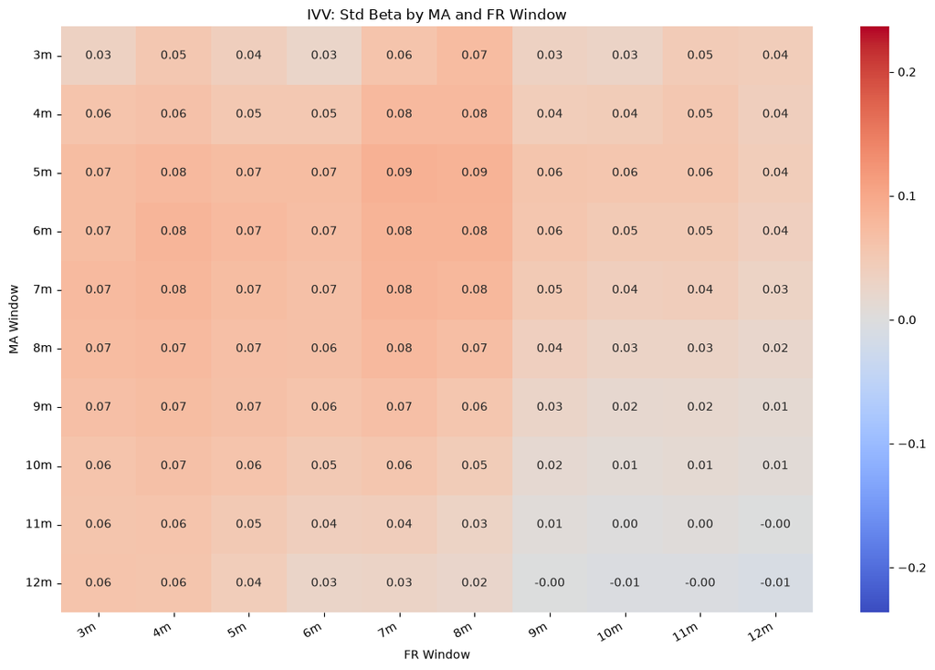

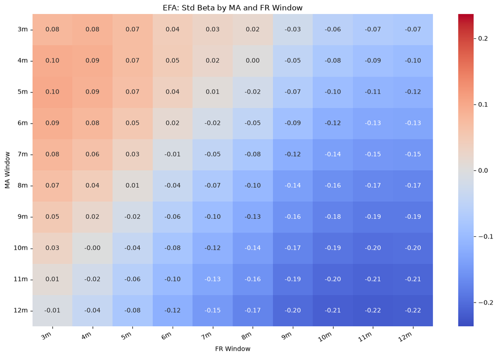

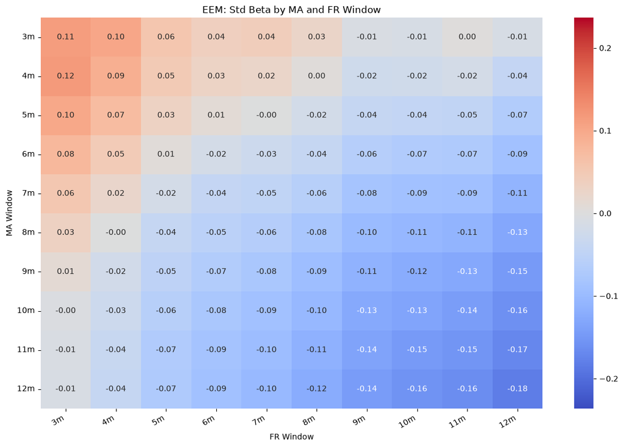

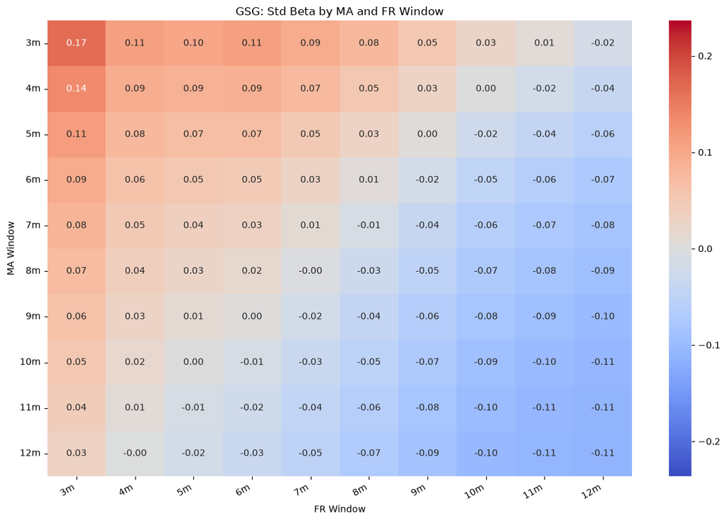

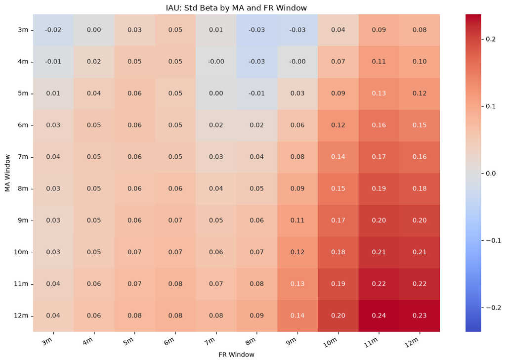

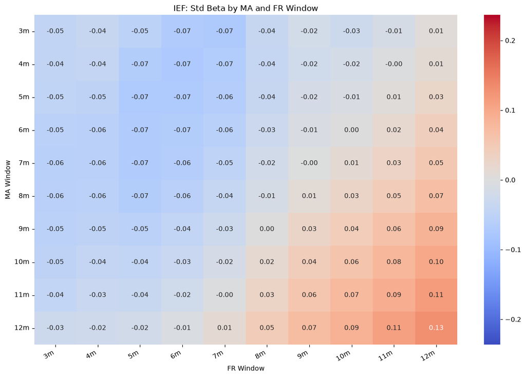

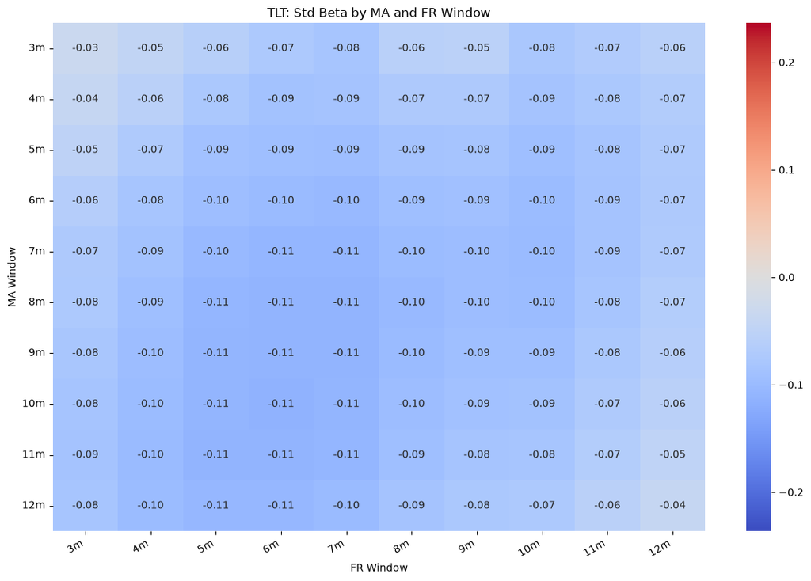

```python
# Symmetric scale so the color range is comparable across funds and nothing clips.
beta_limit = ma_prediction_results["Std_Beta"].abs().max()
prediction_heatmap("Std_Beta", vmin=-beta_limit, vmax=beta_limit, center=0.0)
```

#### Standardized Beta Example #1

To see what underlies one cell of the heatmaps, here is the granular view for IVV using the 7-month MA and the 7-month forward return, with the scatter of the price-MA gap against the forward return (with a fitted OLS line).

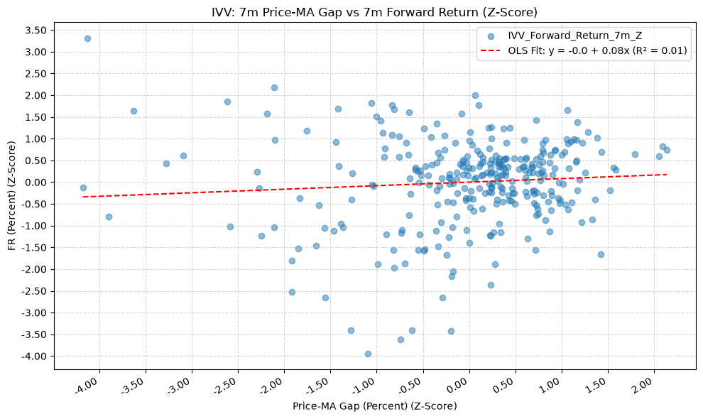

```python
example_fund = "IVV"
example_ma = "7m"
example_fr = "7m"
fr_window = 7

pair_data = pair_data_dict[(example_fund, example_ma, example_fr)]

plot_scatter(
    df=pair_data,
    x_plot_column=f"{example_fund}_Price_MA_Diff_Percent_{example_ma}_Z",
    y_plot_columns=[f"{example_fund}_Forward_Return_{example_fr}_Z"],
    title=f"{example_fund}: {example_ma} Price-MA Gap vs {example_fr} Forward Return (Z-Score)",
    x_label="Price-MA Gap (Percent) (Z-Score)",
    x_format="Decimal",
    x_format_decimal_places=2,
    x_tick_spacing="Auto",
    x_tick_start=None,
    x_tick_rotation=30,
    y_label="FR (Percent) (Z-Score)",
    y_format="Decimal",
    y_format_decimal_places=2,
    y_tick_spacing="Auto",
    y_tick_rotation=0,
    plot_OLS_regression_line=True,
    OLS_column=f"{example_fund}_Forward_Return_{example_fr}_Z",
    plot_Ridge_regression_line=False,
    Ridge_column=None,
    plot_RidgeCV_regression_line=False,
    RidgeCV_column=None,
    regression_constant=True,
    grid=True,
    legend=True,
    export_plot=False,
    plot_file_name=None,
)
```

#### Standardized Beta Example #2

For a second example, we'll use IAU with the 12-month MA and the 12-month forward return, again with the scatter of the price-MA gap against the forward return (with a fitted OLS line).

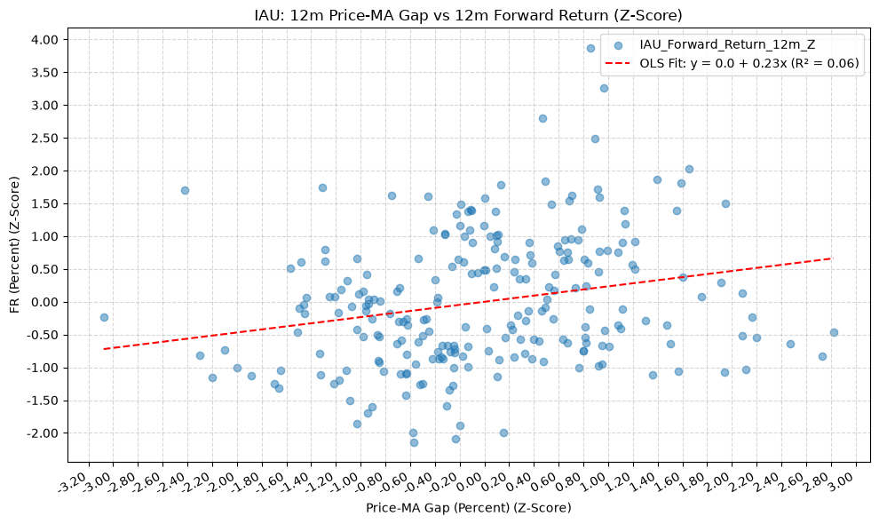

```python
example_fund = "IAU"
example_ma = "12m"
example_fr = "12m"
fr_window = 12

pair_data = pair_data_dict[(example_fund, example_ma, example_fr)]

plot_scatter(
    df=pair_data,
    x_plot_column=f"{example_fund}_Price_MA_Diff_Percent_{example_ma}_Z",
    y_plot_columns=[f"{example_fund}_Forward_Return_{example_fr}_Z"],
    title=f"{example_fund}: {example_ma} Price-MA Gap vs {example_fr} Forward Return (Z-Score)",
    x_label="Price-MA Gap (Percent) (Z-Score)",
    x_format="Decimal",
    x_format_decimal_places=2,
    x_tick_spacing="Auto",
    x_tick_start=None,
    x_tick_rotation=30,
    y_label="FR (Percent) (Z-Score)",
    y_format="Decimal",
    y_format_decimal_places=2,
    y_tick_spacing="Auto",
    y_tick_rotation=0,
    plot_OLS_regression_line=True,
    OLS_column=f"{example_fund}_Forward_Return_{example_fr}_Z",
    plot_Ridge_regression_line=False,
    Ridge_column=None,
    plot_RidgeCV_regression_line=False,
    RidgeCV_column=None,
    regression_constant=True,
    grid=True,
    legend=True,
    export_plot=False,
    plot_file_name=None,
)
```

#### Standardized Beta Example #3

Finally, as a counter example to #2 (which presented positive results), we'll look at EFA with the 12-month MA and the 12-month forward return.

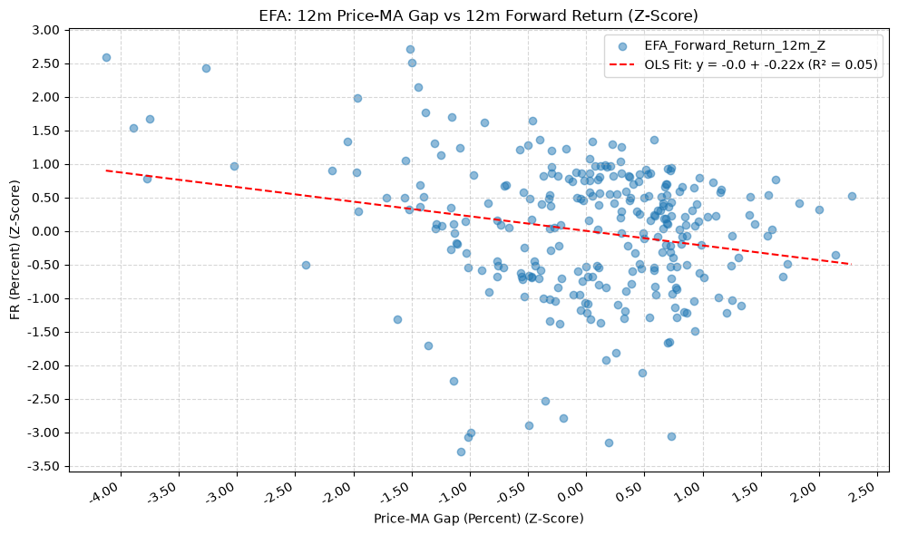

```python
example_fund = "EFA"
example_ma = "12m"
example_fr = "12m"
fr_window = 12

pair_data = pair_data_dict[(example_fund, example_ma, example_fr)]

plot_scatter(
    df=pair_data,
    x_plot_column=f"{example_fund}_Price_MA_Diff_Percent_{example_ma}_Z",
    y_plot_columns=[f"{example_fund}_Forward_Return_{example_fr}_Z"],
    title=f"{example_fund}: {example_ma} Price-MA Gap vs {example_fr} Forward Return (Z-Score)",
    x_label="Price-MA Gap (Percent) (Z-Score)",
    x_format="Decimal",
    x_format_decimal_places=2,
    x_tick_spacing="Auto",
    x_tick_start=None,
    x_tick_rotation=30,
    y_label="FR (Percent) (Z-Score)",
    y_format="Decimal",
    y_format_decimal_places=2,
    y_tick_spacing="Auto",
    y_tick_rotation=0,
    plot_OLS_regression_line=True,
    OLS_column=f"{example_fund}_Forward_Return_{example_fr}_Z",
    plot_Ridge_regression_line=False,
    Ridge_column=None,
    plot_RidgeCV_regression_line=False,
    RidgeCV_column=None,
    regression_constant=True,
    grid=True,
    legend=True,
    export_plot=False,
    plot_file_name=None,
)
```

The difference between examples #2 and #3 is quite interesting. For example #2 using gold, there appears to be a positive relationship between the price-MA gap and the forward return, whereas for example #3 using EFA, this relationship is also evident but in a negative way.

It's difficult to draw any firm conclusions from the heatmaps. Regardless, it is an interesting study into the relationship between price-MA and return.

### Overall Accuracy Lift

Accuracy lift is the overall accuracy minus its naive benchmark, the majority-class rate `max(base rate, 1 - base rate)` (i.e. how much the price-MA sign beats simply always predicting whichever direction is more common). The heatmap is centered on zero, so red cells add value over the naive benchmark, and blue cells do not.

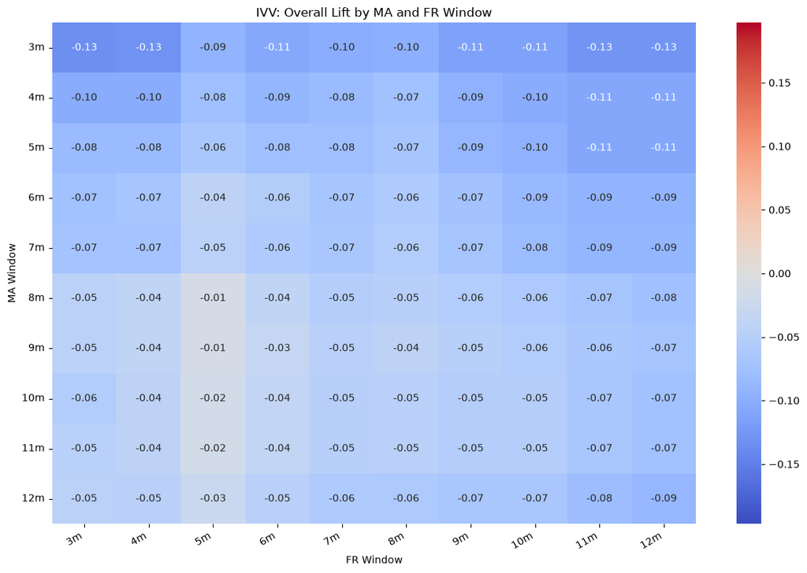

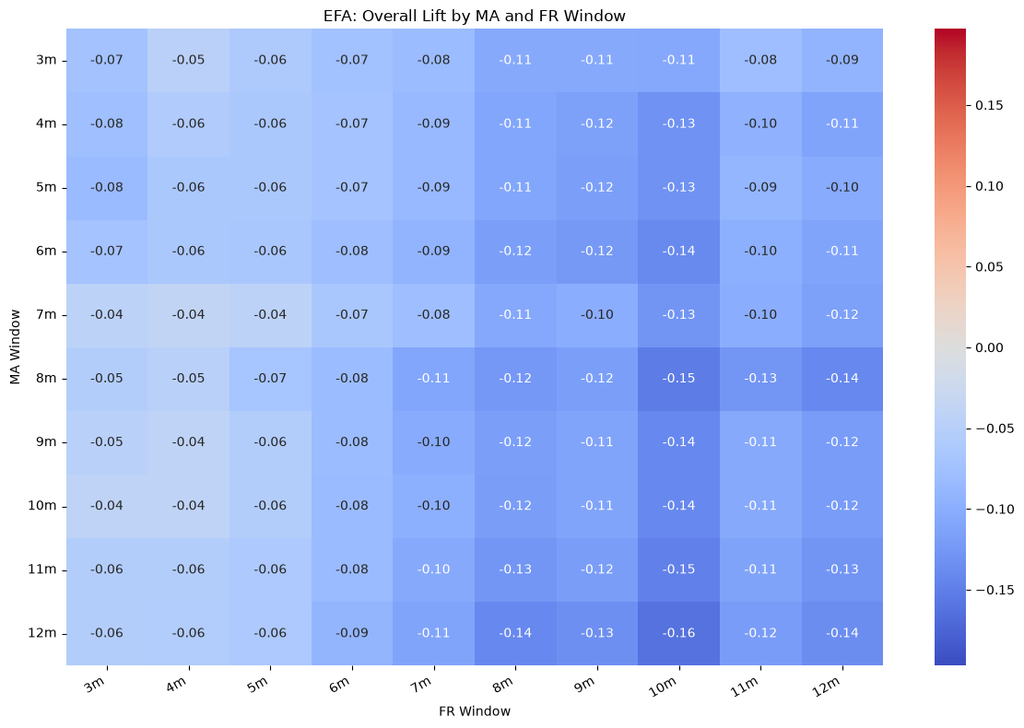

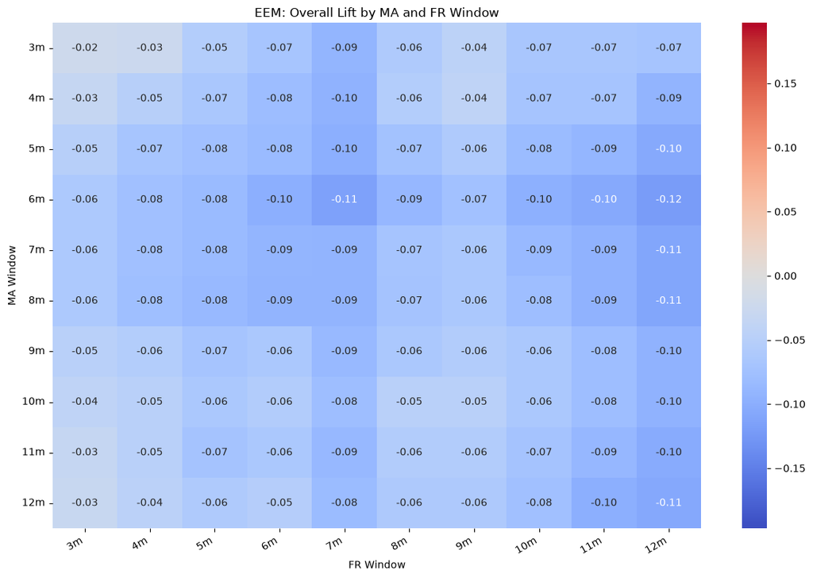

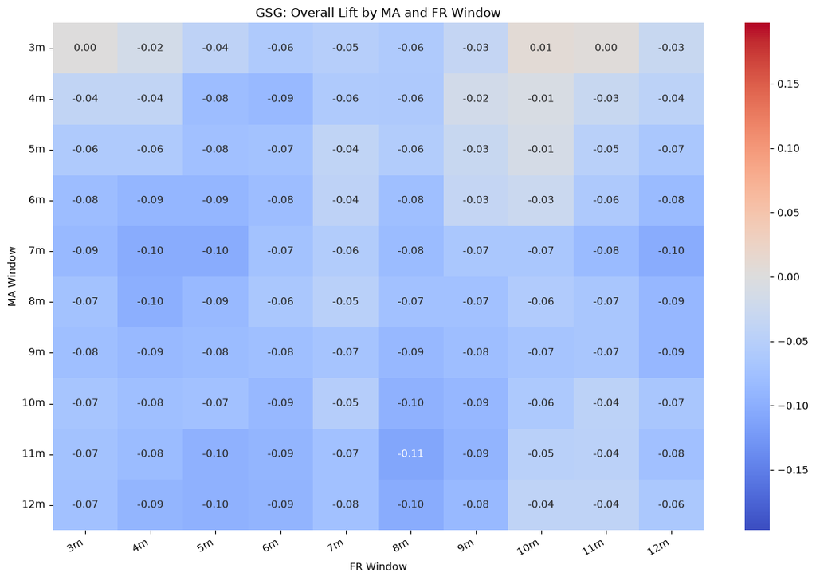

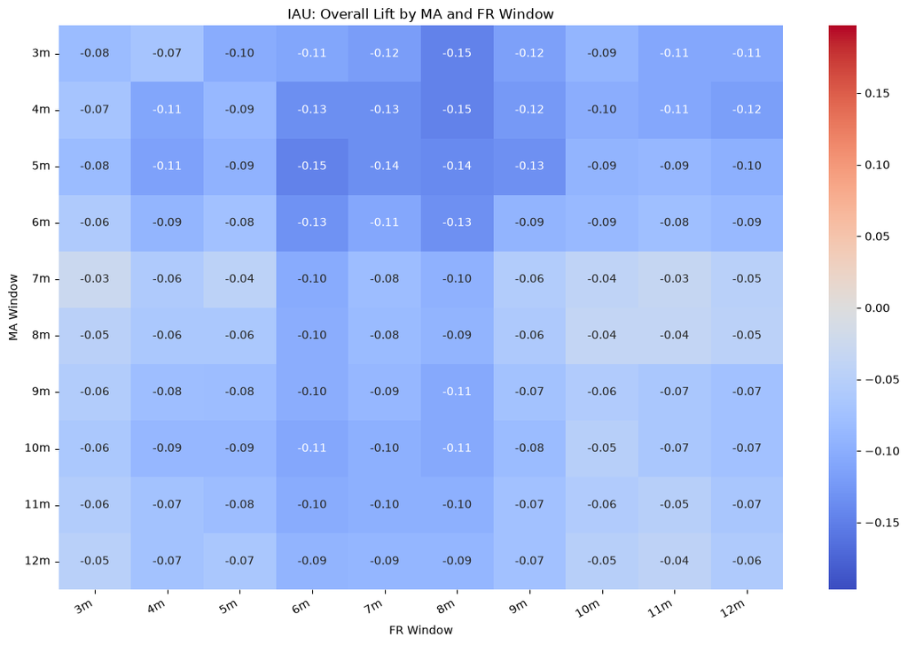

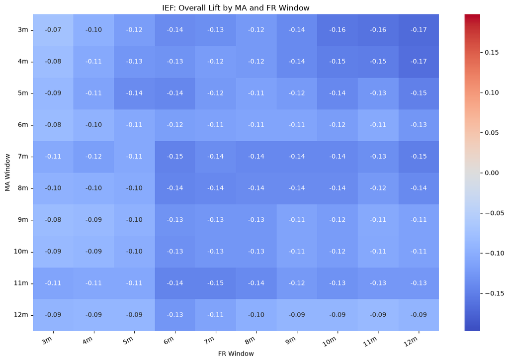

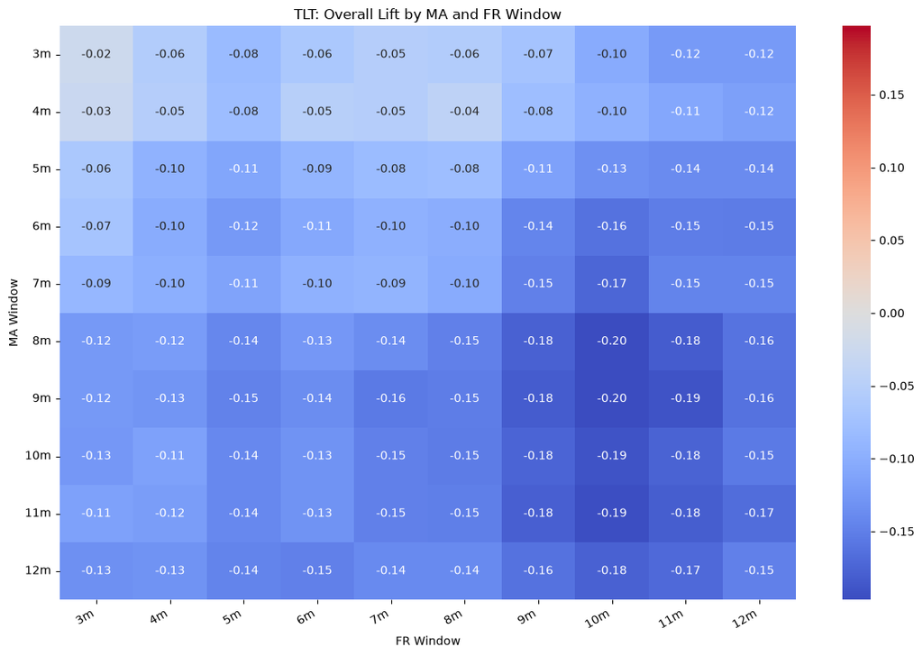

```python
# Symmetric scale around zero so the color encodes sign and magnitude of the lift.
overall_lift_limit = ma_prediction_results["Overall_Lift"].abs().max()
prediction_heatmap("Overall_Lift", vmin=-overall_lift_limit, vmax=overall_lift_limit, center=0.0)
```